# Inner West LGA Sales and Rent Report

# 6 Rent in the Inner West

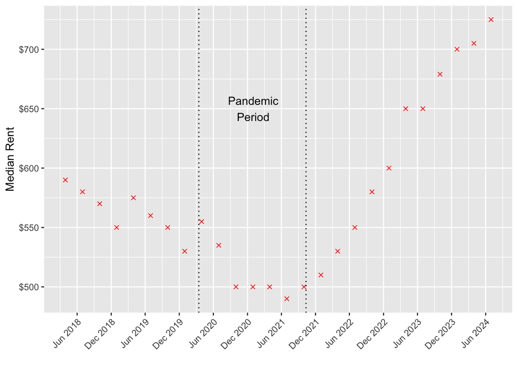

Figure 1: Median weekly rent in the Inner West LGA from January 2018 to July 2024.

```r
fig_total_rent <- inner_west_rents |>
  dplyr::filter(dwelling_type == "Total"& no_of_bedrooms == "Total") |>
  ggplot() +
  aes(x = date, y = median_rent_price) +
  geom_point(colour="red",shape="cross") +
  scale_x_date(date_breaks = "6 months",date_labels = "%b %Y") +
  scale_y_continuous(labels=scales::dollar_format()) +
  geom_vline(xintercept=as.Date("2020-03-15"),linetype="dotted") +
  geom_vline(xintercept=as.Date("2021-10-11"),linetype="dotted") +
  annotate("text",label="Pandemic\nPeriod",x=as.Date("2021-01-01"),y=650) +
  theme(axis.text.x=element_text(angle = 45, vjust=1,hjust=1)) +
  labs(x = "",y = "Median Rent")
fig_total_rent
```

Median rent in the Inner West LGA was trending downwards from January 2018 to January 2020, as shown in Figure 1 . In the quarter ending March 2020 (the first quarter ending within the pandemic period) was $555 per week. This was $35 per week less than the two years earlier in the quarter ending March 2018. In the quarter ending June 2021, the lowest median weekly rent in the period this report is concerned with is recorded at $490 per week. This quarter marks a steady trend upwards, barring the March and June quarters of 2023 where the median weekly rent remained the same, with the last quarter this report looks at recording a median weekly rent of $725. Between that minima recorded in June 2021 and the latest reported quarter in June 2024, median rents rose by $235.

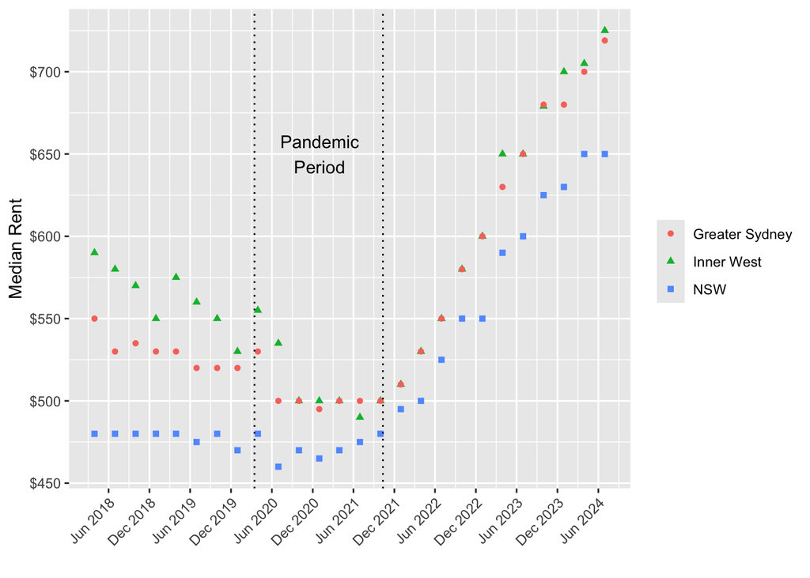

Figure 2: Inner West (green triangle), greater Sydney (red circle) and NSW (blue square) median rents from January 2018 to June 2024.

```r
fig_comp <- rents_df |>
  dplyr::filter(
    ((lga == "Inner West" & greater_sydney == "Total") |
      (lga == "Total" & greater_sydney == "Greater Sydney") |
      (lga == "Total" & greater_sydney == "Total")) &
      gmr == "Total" & rings == "Total" &
      dwelling_type == "Total" & no_of_bedrooms == "Total"
  ) |>
  dplyr::mutate(
    region_lab = case_when(
      lga == "Inner West" ~ "Inner West",
      greater_sydney == "Greater Sydney" ~ "Greater Sydney",
      TRUE ~ "NSW"
    )
  ) |> ggplot() +
  aes(x = date,y=median_rent_price, colour = factor(region_lab),shape=factor(region_lab)) +
  geom_point() +
  scale_x_date(date_breaks = "6 months",date_labels = "%b %Y") +
  scale_y_continuous(labels=scales::dollar_format()) +
  geom_vline(xintercept=as.Date("2020-03-15"),linetype="dotted") +
  geom_vline(xintercept=as.Date("2021-10-11"),linetype="dotted") +
  annotate("text",label="Pandemic\nPeriod",x=as.Date("2021-01-01"),y=650) +
  theme(axis.text.x=element_text(angle = 45, vjust=1,hjust=1)) +
  labs(x = "",y = "Median Rent",colour = "",shape="")

fig_comp
```

As shown in Figure 2, there is a notable difference in NSW, Greater Sydney, and Inner West median rents. NSW rents were relatively stable pre-pandemic, and Greater Sydney rents followed a slight downward trend. During the pandemic, Greater Sydney and Inner West rents followed a similar trend, whilst NSW rents actually began lifting substantially earlier than the Inner West and Sydney. Post-pandemic, Inner West, Greater Sydney, and whole of NSW median rents have been on a pretty steady upwards trend.

```r
lm_iw_rent_df = inner_west_rents |>
  dplyr::filter(dwelling_type == "Total" & no_of_bedrooms == "Total" & date > as.Date("2021-01-01")) |>
  dplyr::mutate(
    timestep = as.integer(date - as.Date("2021-03-30")) / 7
  )

lm_iw_rent = lm(median_rent_price ~ timestep,data=lm_iw_rent_df)

summary(lm_iw_rent)
cor(lm_iw_rent_df$timestep,lm_iw_rent_df$median_rent_price)
```

[output not shown]

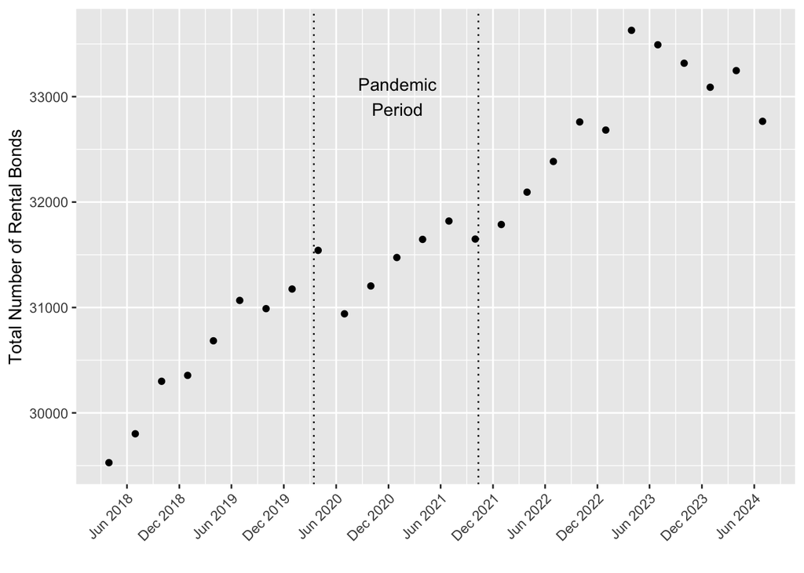

Figure 3: Total number of rental bonds in the Inner West over the reporting period.

```r
fig_iw_bonds_new = inner_west_rents |>
  dplyr::filter(dwelling_type == "Total" & no_of_bedrooms == "Total") |>
  ggplot() +
  aes(x = date, y = no_of_bonds_total) +
  scale_x_date(date_breaks = "6 months",date_labels = "%b %Y") +
  geom_vline(xintercept=as.Date("2020-03-15"),linetype="dotted") +
  geom_vline(xintercept=as.Date("2021-10-11"),linetype="dotted") +
  annotate("text",label="Pandemic\nPeriod",x=as.Date("2021-01-01"),y=33000) +
  theme(axis.text.x=element_text(angle = 45, vjust=1,hjust=1)) +
  labs(x = "", y = "Total Number of Rental Bonds") +
  geom_point()

fig_iw_bonds_new
```

Consider the reasons why total bonds would shrink. Properties may have been taken off the rental market altogether (sold to owner-occupiers, renovations, sold to developers), or properties may not have been able to find renters.

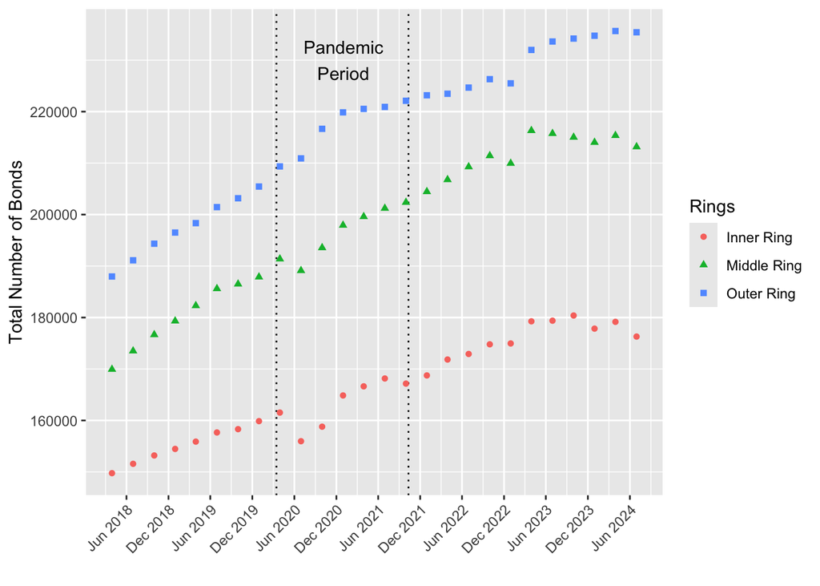

Figure 4: Total number of bonds in the inner, middle, and outer rings of Sydney over the reporting period.

```r
fig_rings_bonds_total <- rents_df |> dplyr::filter(
                            lga == "Total" &
                            (rings == "Inner Ring" | rings == "Middle Ring" | rings == "Outer Ring") &
                            no_of_bedrooms == "Total" &
                            dwelling_type == "Total" &
                            gmr == "Total" &
                            greater_sydney == "Total"
                          ) |>
  ggplot() +
  aes(x = date, y = no_of_bonds_total , colour = rings, shape = rings) +
  scale_x_date(date_breaks = "6 months",date_labels = "%b %Y") +
  geom_vline(xintercept=as.Date("2020-03-15"),linetype="dotted") +
  geom_vline(xintercept=as.Date("2021-10-11"),linetype="dotted") +
  annotate("text",label="Pandemic\nPeriod",x=as.Date("2021-01-01"),y=230000) +
  theme(axis.text.x=element_text(angle = 45, vjust=1,hjust=1)) +
  labs(x = "", y = "Total Number of Bonds",shape = "Rings",colour = "Rings") +
  geom_point()

fig_rings_bonds_total
```

The ring classification was introduced by the Bureau of Communications, Arts and Regional Research (BCARR) for dividing Australian cities. The inner ring contains a cities CBD and inner suburbs, of which the Inner West LGA belongs to. The middle ring contains lower density housing but have some high density areas, examples of middle ring LGA’s include Canterbury-Bankstown and Parramatta. The outer ring refers to the outer limits of a city, examples include Blacktown and Hornsby LGA.

## References

[1]

New South Wales Department of Communities and Justice, “Housing rent and sales.” Accessed: Oct. 15, 2024. [Online]. Available: https://dcj.nsw.gov.au/about-us/families-and-communities-statistics/housing-rent-and-sales.html

[2]

Inner West Council, “Community Profile.” Accessed: Oct. 15, 2024. [Online]. Available: https://www.innerwest.nsw.gov.au/explore/getting-around/our-community/community-profile

[3]

Australian Bureau of Statistics, “Inner West, 2021 Census All persons QuickStats.” Accessed: Oct. 15, 2024. [Online]. Available: https://www.abs.gov.au/census/find-census-data/quickstats/2021/LGA14170